## **Yellow-footed rock-wallaby**

### Blamed on cats

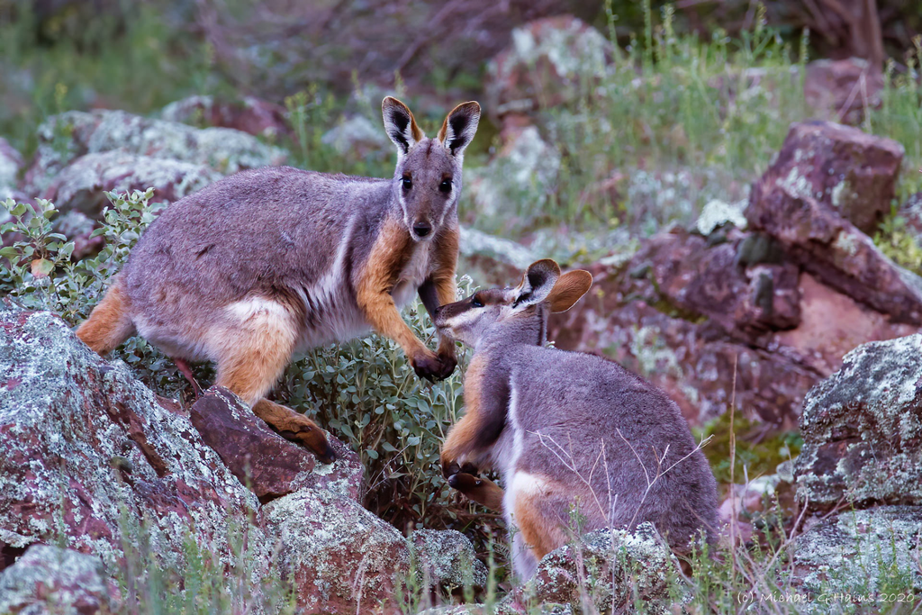

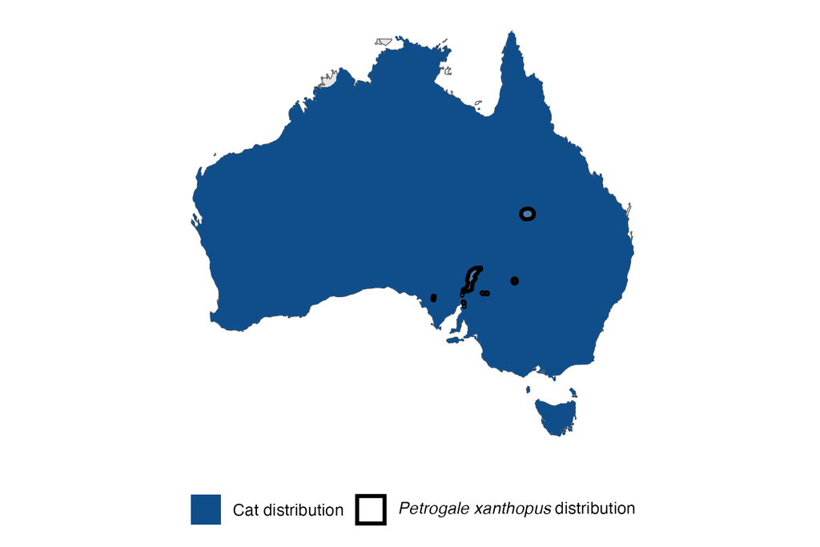

IUCN status: **Near Threatened**

EPBC Predator Threat Rating: **High**

IUCN claim: *Not attributed*

### Studies in support

Rock-wallaby remains were found in the cat’s diet (Doherty et al. 2015).

### Studies not in support

Rock-wallaby remains were not found in the cat’s diet (Lapidge & Henshall 2001). Stobo-Wilson et al. (2020) reported that rock-wallabies were detected at 2 of 4 cat-present sites, but no statistical analysis was provided.

### Is the threat claim evidence-based?

No studies were found evidencing a negative association between cats and yellow-footed rock-wallaby population trends.

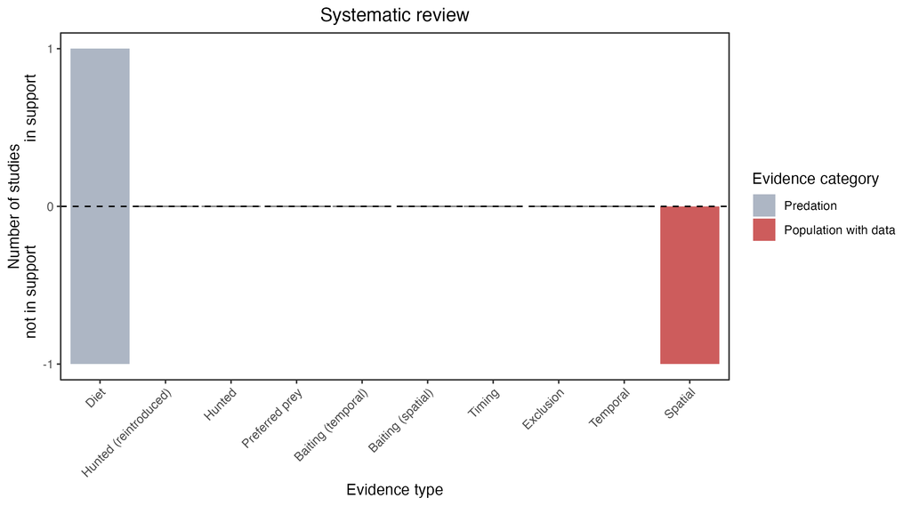

**Evidence linking *Petrogale xanthopus* to cats.** Systematic review of evidence for an association between *Petrogale xanthopus* and cats. Positive studies are in support of the hypothesis that *cats* contribute to the decline of Petrogale xanthopus, negative studies are not in support. Predation studies include studies documenting hunting or scavenging; baiting studies are associations between poison baiting and threatened mammal abundance where information on predator abundance is not provided; population studies are associations between threatened mammal and predator abundance. Gold borders indicate studies that meet qualities of scientific rigour. See methods section in Wallach and Lundgren 2025 for details on evidence categories.

### References

Doherty, T.S., Davis, R.A., van Etten, E.J., Algar, D., Collier, N., Dickman, C.R., Edwards, G., Masters, P., Palmer, R. and Robinson, S., 2015. A continental‐scale analysis of feral cat diet in Australia. Journal of Biogeography, 42(5), pp.964-975.

EPBC. (2015) Threat Abatement Plan for Predation by Feral Cats. Environment Protection and Biodiversity Conservation Act 1999, Department of Environment, Government of Australia. (Table A1).

IUCN Red List. https://www.iucnredlist.org/ Accessed June 2023

Lapidge, S.J. and Henshall, S., 2001. Diet of foxes and cats, with evidence of predation on yellow-footed rock-wallabies (Petrogale xanthopus Celeris) by foxes in southwsetern Queensland. Australian Mammalogy, 23(1), pp.47-52.

Stobo-Wilson, A.M., Brandle, R., Johnson, C.N. and Jones, M.E., 2020. Management of invasive mesopredators in the Flinders Ranges, South Australia: effectiveness and implications. Wildlife Research, 47(8), pp.720-730.

Wallach A.D., Lundgren E.J. (2025) Review of evidence that foxes and cats cause extinctions of Australia’s endemic mammals. BioScience. DOI: 10.1093/biosci/biaf046